```r
link='https://github.com/ComputationalThinkingGroup5/Merge/raw/master/MergedData.csv'
# a RDS file from the web needs:
mergedFile=read.csv(link)
```

```r
str(mergedFile,width = 50,strict.width='cut')
```

```
## 'data.frame':    162 obs. of  4 variables:
##  $ country            : chr  "Cambodia" "Niger""..
##  $ percentunemployment: num  0.3 0.3 0.7 0.78 0...
##  $ pct_GDP_exp        : num  2.2 3.5 2.9 4.8 4.8..
##  $ percentbirthrate   : num  1.34 3.65 1.46 0.75..
```

```r
# hypothesis 1: percentunemployment increases as percentbirthrate advances:
hypo1=formula(percentunemployment~ percentbirthrate)
# hypothesis 2: percentunemployment increases as percentbirthrate and pct_GDP_exp advance:
hypo2=formula(percentunemployment~ percentbirthrate * pct_GDP_exp)
```

```r
#
# results
gauss1=glm(hypo1,
           data = mergedFile,
           family = 'gaussian')

gauss2=glm(hypo2,
           data = mergedFile,
           family = 'gaussian')
```

#3.See results: ·First Hypothesis

```r
summary(gauss1)
```

```
##
## Call:
## glm(formula = hypo1, family = "gaussian", data = mergedFile)
##
## Deviance Residuals:
##     Min       1Q   Median       3Q      Max
## -15.166   -5.531   -2.877    1.528   63.857
##
## Coefficients:
##                  Estimate Std. Error t value Pr(>|t|)
## (Intercept)        7.5423     1.0753   7.014 6.16e-11 ***
## percentbirthrate   2.1710     0.7683   2.826  0.00532 **
## ---
## Signif. codes:  0 '***' 0.001 '**' 0.01 '*' 0.05 '.' 0.1 ' ' 1
##
## (Dispersion parameter for gaussian family taken to be 100.6676)
##
##     Null deviance: 16911  on 161  degrees of freedom
## Residual deviance: 16107  on 160  degrees of freedom
## AIC: 1210.8
##
## Number of Fisher Scoring iterations: 2
```

·Second Hypothesis

```r
summary(gauss2)
```

```
##
## Call:
## glm(formula = hypo2, family = "gaussian", data = mergedFile)
##
## Deviance Residuals:
##     Min       1Q   Median       3Q      Max
## -13.654   -5.713   -2.580    1.972   60.820
##
## Coefficients:
##                              Estimate Std. Error t value Pr(>|t|)
## (Intercept)                    6.1840     2.8351   2.181   0.0306 *
## percentbirthrate              -0.7806     2.0912  -0.373   0.7095
## pct_GDP_exp                    0.2716     0.5519   0.492   0.6233
## percentbirthrate:pct_GDP_exp   0.7568     0.4563   1.658   0.0992 .
## ---
## Signif. codes:  0 '***' 0.001 '**' 0.01 '*' 0.05 '.' 0.1 ' ' 1
##
## (Dispersion parameter for gaussian family taken to be 98.30933)
##
##     Null deviance: 16911  on 161  degrees of freedom
## Residual deviance: 15533  on 158  degrees of freedom
## AIC: 1209
##
## Number of Fisher Scoring iterations: 2
```

#4.Search for better model:

```r
anova(gauss1,gauss2,test="Chisq")
```

```
## Analysis of Deviance Table
##
## Model 1: percentunemployment ~ percentbirthrate
## Model 2: percentunemployment ~ percentbirthrate * pct_GDP_exp
##   Resid. Df Resid. Dev Df Deviance Pr(>Chi)
## 1       160      16107
## 2       158      15533  2   573.94  0.05398 .
## ---
## Signif. codes:  0 '***' 0.001 '**' 0.01 '*' 0.05 '.' 0.1 ' ' 1
```

```r
library(rsq)
rsq(gauss2,adj=T)
```

```
## [1] 0.06403427
```

Finally, some nice summary plots: You can see the coefficient estimates like this:

```r
library(dotwhisker)
```

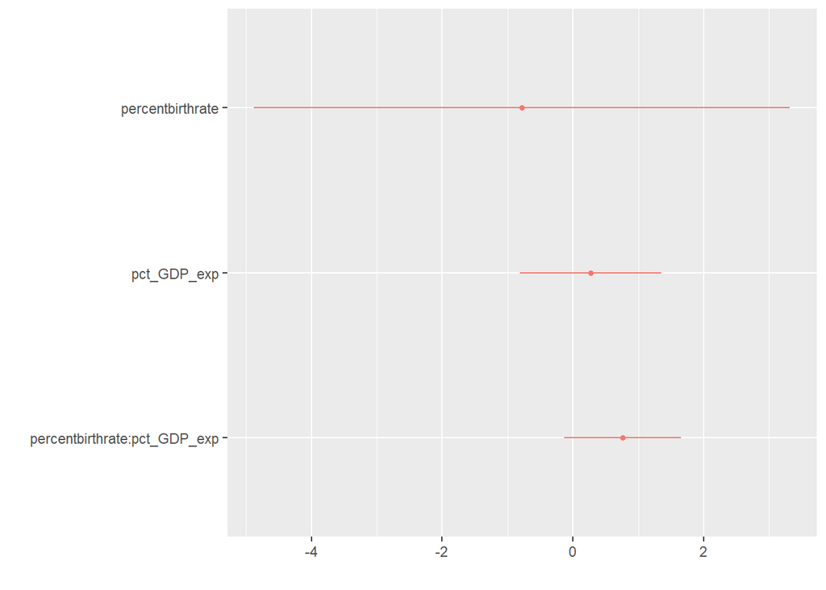

```r
dwplot(gauss2,by_2sd = F)
```

You can also use margins library:

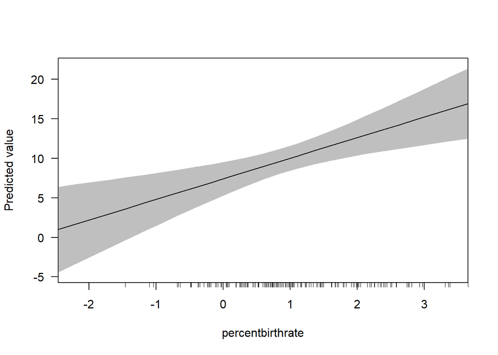

```r
library(margins)

cplot(gauss2,'percentbirthrate')
```

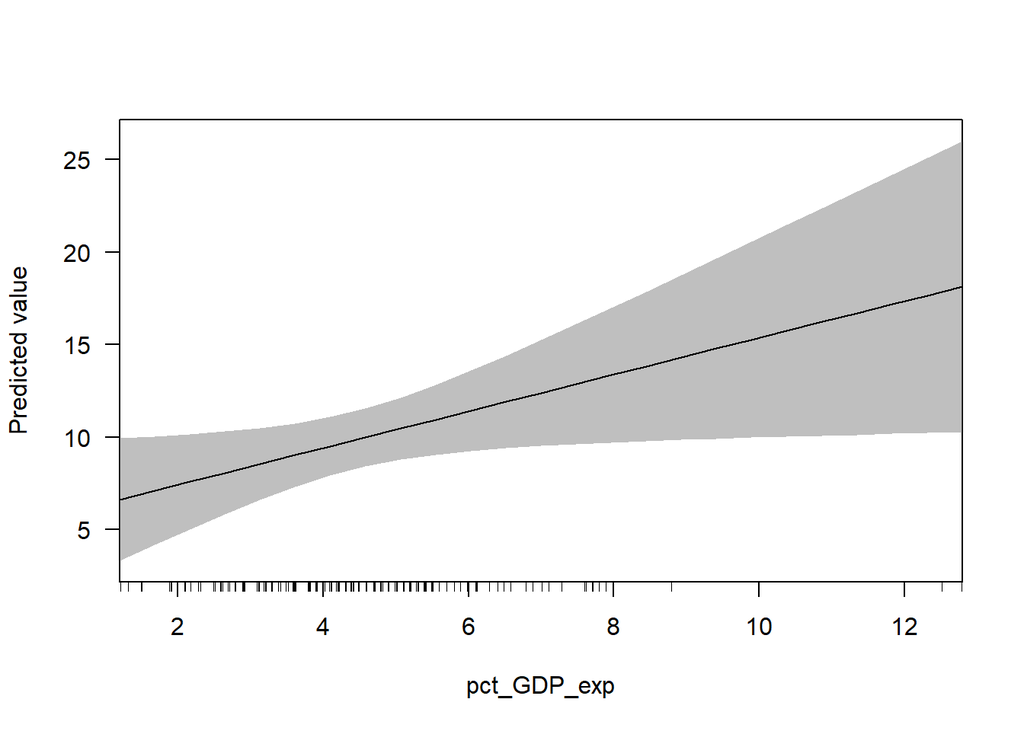

```r
cplot(gauss2,'pct_GDP_exp')
```

And the interaction:

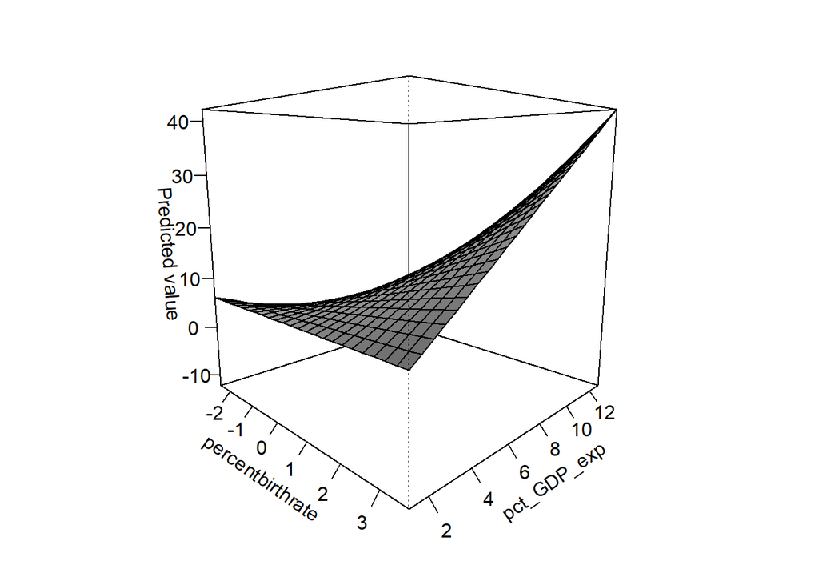

```r
persp(gauss2)
```

Binary outcome In this situation you have a binary dependent variable, which we do not currently have:

```r
mergedFile$percentunemploymentdico=ifelse(mergedFile$percentunemployment>median(mergedFile$percentunemployment,
                                        na.rm = T),
                      1,0)
```

Now we have it.

```r
hypoDico1=formula(percentunemploymentdico~ percentunemployment)
hypoDico2=formula(percentunemploymentdico~ percentunemployment * pct_GDP_exp)
```

2.Reformat

```r
mergedFile$mergedFiledico=factor(mergedFile$percentunemploymentdico)
```

3.Compute regression models:

```r
Logi1=glm(hypoDico1,data = mergedFile,
          family = "binomial")
Logi2=glm(hypoDico2,data = mergedFile,
          family = "binomial")
```

4.See results: ·First Hypothesis:

```r
summary(Logi1)
```

```
##
## Call:
## glm(formula = hypoDico1, family = "binomial", data = mergedFile)
##
## Deviance Residuals:
##        Min          1Q      Median          3Q         Max
## -1.830e-03  -2.000e-08   0.000e+00   2.000e-08   2.094e-03
##
## Coefficients:
##                     Estimate Std. Error z value Pr(>|z|)
## (Intercept)          -3436.3    81284.3  -0.042    0.966
## percentunemployment    526.6    12450.9   0.042    0.966
##
## (Dispersion parameter for binomial family taken to be 1)
##
##     Null deviance: 2.2458e+02  on 161  degrees of freedom
## Residual deviance: 7.7324e-06  on 160  degrees of freedom
## AIC: 4
##
## Number of Fisher Scoring iterations: 25
```

3.Second Hypothesis:

```r
summary(Logi2)
```

```
##
## Call:
## glm(formula = hypoDico2, family = "binomial", data = mergedFile)
##
## Deviance Residuals:
##        Min          1Q      Median          3Q         Max
## -6.566e-04  -2.000e-08   0.000e+00   2.000e-08   6.917e-04
##
## Coefficients:
##                                 Estimate Std. Error z value Pr(>|z|)
## (Intercept)                     -1934.37   93064.31  -0.021    0.983
## percentunemployment               290.89   13977.42   0.021    0.983
## pct_GDP_exp                       143.55    7241.72   0.020    0.984
## percentunemployment:pct_GDP_exp   -20.39    1060.78  -0.019    0.985
##
## (Dispersion parameter for binomial family taken to be 1)
##
##     Null deviance: 2.2458e+02  on 161  degrees of freedom
## Residual deviance: 1.3617e-06  on 158  degrees of freedom
## AIC: 8
##
## Number of Fisher Scoring iterations: 25
```

5.Search for better model:

```r
lmtest::lrtest(Logi1,Logi2)
```

```
## Likelihood ratio test
##
## Model 1: percentunemploymentdico ~ percentunemployment
## Model 2: percentunemploymentdico ~ percentunemployment * pct_GDP_exp
##   #Df      LogLik Df Chisq Pr(>Chisq)
## 1   2 -3.8662e-06
## 2   4 -6.8090e-07  2     0          1
```

6.Logistics regression coefficients do not offer marginal effects on how much eah variable affects the probability of the ‘1’ outcome. We can get it using margins library:

```r
library(margins)
(marginsINFO = margins(Logi2))
```

```
## Average marginal effects
```

```
## glm(formula = hypoDico2, family = "binomial", data = mergedFile)
```

```
##  percentunemployment pct_GDP_exp
##            1.691e-05   4.696e-08
```

```r
(marginsSUMM=summary(marginsINFO))
```

```
##               factor    AME     SE      z      p   lower  upper
##          pct_GDP_exp 0.0000 0.0000 0.0014 0.9989 -0.0001 0.0001
##  percentunemployment 0.0000 0.0089 0.0019 0.9985 -0.0175 0.0175
```

I can use that information like this:

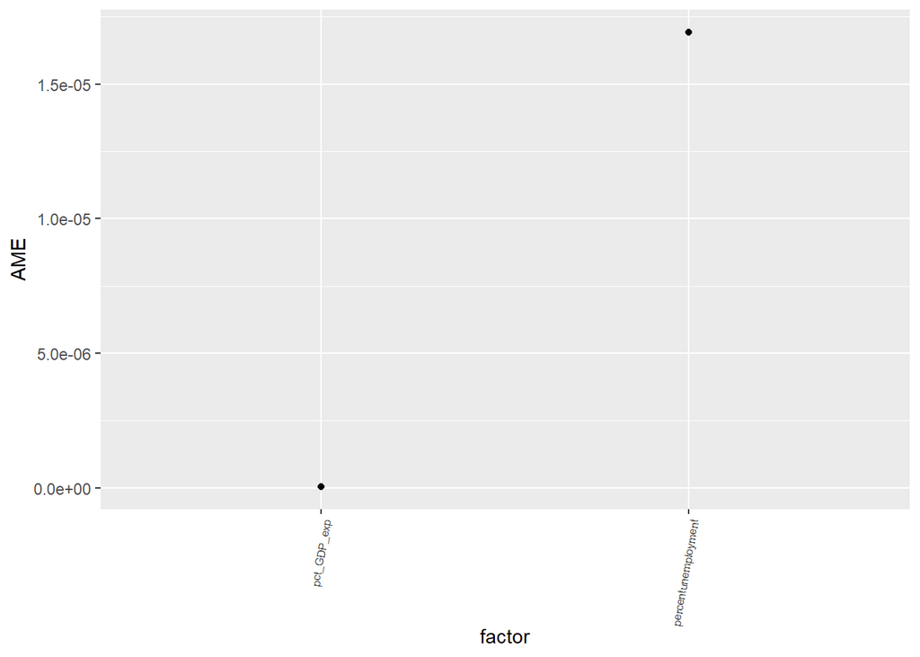

```r
base= ggplot(marginsSUMM,
             aes(x=factor, y=AME))
base= base + geom_point()

plotMargins = base + theme(axis.text.x = element_text(angle = 80,size = 6,hjust = 1))
plotMargins
```

We can add the the confidence intervals:

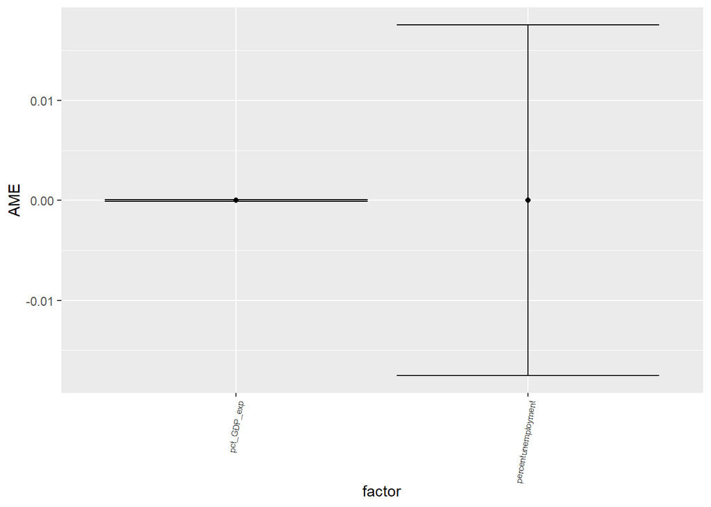

```r
plotMargins +  geom_errorbar(aes(ymin=lower,
                                 ymax=upper))
```

It is a good idea to use the indivual plots per variable:

[figure not shown]

```r
cplot(Logi2, "percentbirthrate")
```

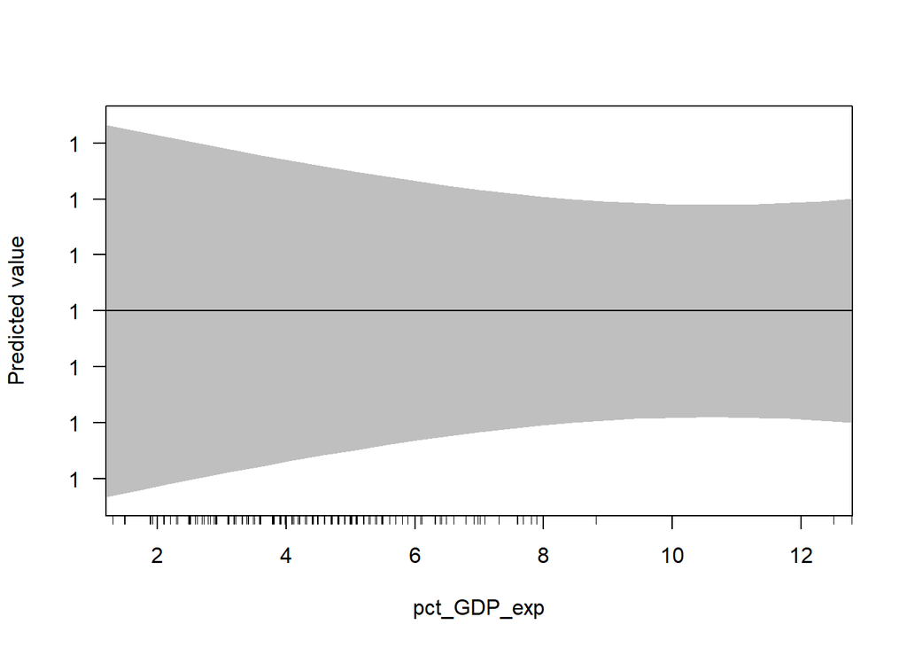

```r
cplot(Logi2, "pct_GDP_exp")
```

And for the interaction:

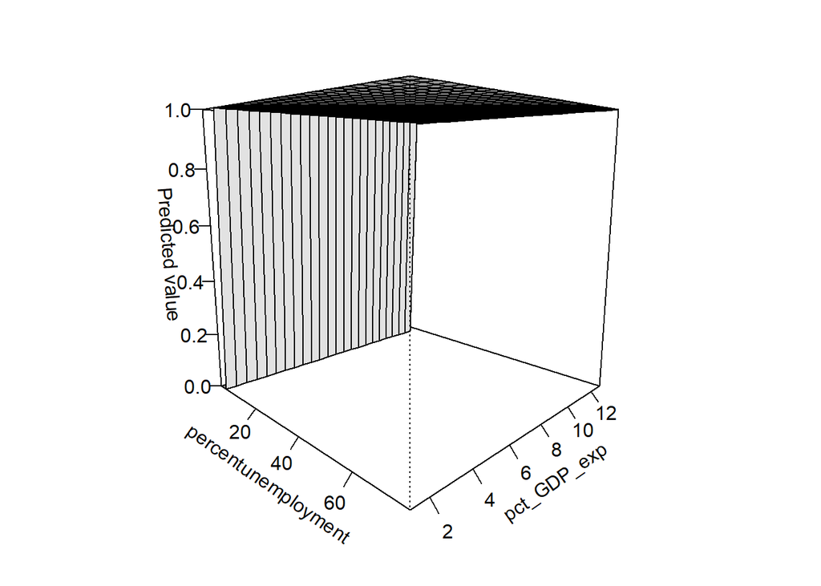

```r
persp(Logi2)
```

```r
tinytex::install_tinytex()
```